# Coursera capstone project: data exploration

S. Massie

Here, I focus on getting the data, cleaning it, and counting commonly occurring words, using the three US-English corpora.

The last section focuses on findings and suggests some possible directions for the final project.

### Getting data

Download files, extract, and set working directory:

```r
# # Download files
# myURL <- "https://d396qusza40orc.cloudfront.net/dsscapstone/dataset/Coursera-SwiftKey.zip"
#
# dateDownloaded <- date()
#
# if(!file.exists("rawdata.zip")){
#     download.file(myURL, destfile = "rawdata.zip", method = "curl")
#     unzip("rawdata.zip")
# }
```

Load data into memory. Since most files are very large, store only a random sample in order to reduce processing time later.

```r
set.seed(1228)

sampleText <- function(con, x=0.01){
    # Read file into memory
    input <- readLines(con,n=-1)
    close(con)

    # Sample x% of the data (1% by default) without replacement
    sample(input, size = as.integer(length(input)*x))
}

ENtwit <- sampleText(file("/Users/SRM/Desktop/Coursera/10 Capstone Project/final/en_US/en_US.twitter.txt"))
ENblog <- sampleText(file("/Users/SRM/Desktop/Coursera/10 Capstone Project/final/en_US/en_US.blogs.txt"))
ENnews <- sampleText(file("/Users/SRM/Desktop/Coursera/10 Capstone Project/final/en_US/en_US.news.txt"))
```

Store as “corpus” data type. This allows us to use special text-mining functions from the “tm” package.

```r
library(tm)

ENtwit_C <- VCorpus(DataframeSource(data.frame(ENtwit)),
                    readerControl = list(language = "en_US"))
ENblog_C <- VCorpus(DataframeSource(data.frame(ENblog)),
                    readerControl = list(language = "en_US"))
ENnews_C <- VCorpus(DataframeSource(data.frame(ENnews)),
                    readerControl = list(language = "en_US"))
```

### Preprocessing

Load profanity list:

```r
# Load profanity list from Ryan Lewis's profanity list downloaded from GitHub (originally from Google)

shitList <- readLines("/Users/SRM/Desktop/Coursera/10 Capstone Project/google_twunter_lol.txt")
```

Apply function to remove profanity, punctuation, stopwords, and whitespace:

```r
wordClean <- function(text){
    text <- tm_map(text, removeWords, shitList)
    text <- tm_map(text, removePunctuation)
    text <- tm_map(text, removeWords, stopwords("en"))
    text <- tm_map(text, stripWhitespace)
}

ENtwit_C <- wordClean(ENtwit_C)
ENblog_C <- wordClean(ENblog_C)
ENnews_C <- wordClean(ENnews_C)
```

### Exploration

Get line lengths:

```r
Ltwit <- data.frame(chars = sapply(ENtwit, nchar))
Lblog <- data.frame(chars = sapply(ENblog, nchar))
Lnews <- data.frame(chars = sapply(ENnews, nchar))
```

```r
# Function to tokenize into words
wordify <- function(text){
    unlist(strsplit(as.character(text), "[[:space:]]+"))
}

# Function to get word counts
wordcount <- function(x){
    length(wordify(x))
}

# Get counts
Ltwit$words <- sapply(ENtwit, wordcount)
Lblog$words <- sapply(ENblog, wordcount)
Lnews$words <- sapply(ENnews, wordcount)
```

Plot findings:

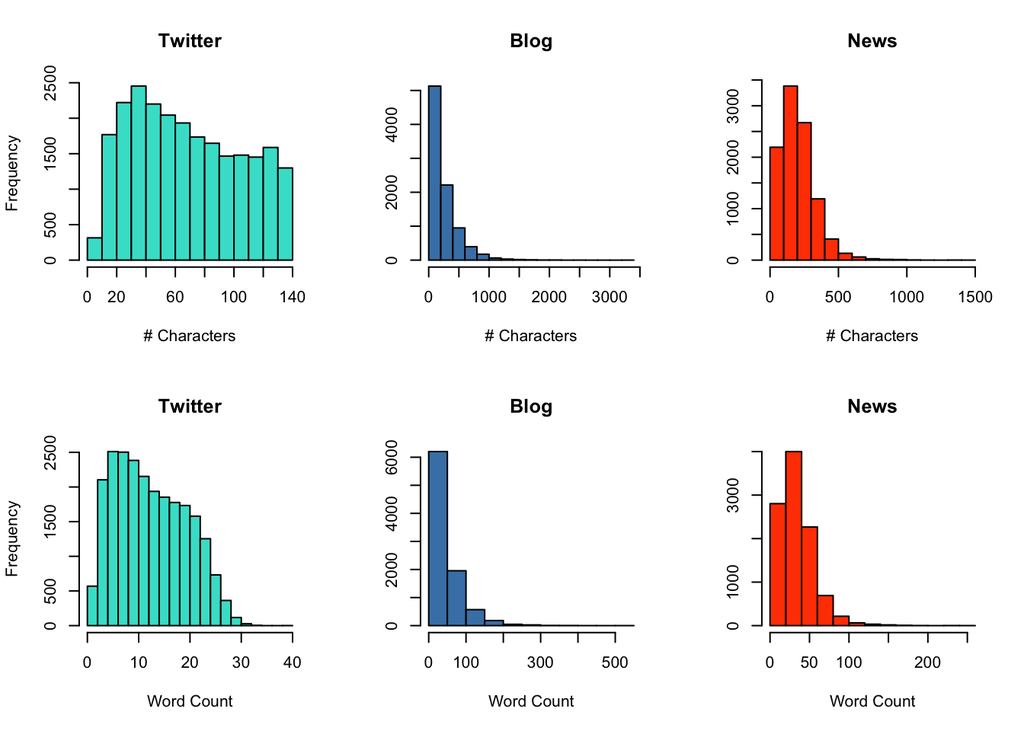

```r
par(mfrow = c(2,3))

hist(Ltwit$chars, main = "Twitter", xlab = "# Characters", col = "turquoise")
hist(Lblog$chars, main = "Blog", xlab = "# Characters", ylab = "", col = "steelblue")
hist(Lnews$chars, main = "News", xlab = "# Characters", ylab = "", col = "orangered")

hist(Ltwit$words, main = "Twitter", xlab = "Word Count", col = "turquoise")
hist(Lblog$words, main = "Blog", xlab = "Word Count", ylab = "", col = "steelblue")
hist(Lnews$words, main = "News", xlab = "Word Count", ylab = "", col = "orangered")
```

```r
par(mfcol = c(1,1))
```

Which words are most common across the entire corpus? Get top words for each corpus:

```r
# Function to extract top words from all documents in a (clean) Corpus:
topWords <- function(text, nwords=10){
    dtm <- DocumentTermMatrix(text)
    tmp <- inspect(dtm)
    return(head(sort(colSums(tmp),decreasing=TRUE),nwords))
}
    # This approach is computationally expensive, may wish to cache the dtm later


# Apply function to each dataset to get top words
topTwit <- topWords(ENtwit_C, 50)
topBlog <- topWords(ENblog_C, 50)
topNews <- topWords(ENnews_C, 50)
```

Display results:

```r
# Display in table format
library(xtable)

a <- cbind(names(topTwit),topTwit,names(topBlog),topBlog,names(topNews),topNews)
colnames(a) <- c("Twitter", "", "Blogs","","News","")
rownames(a) <- 1:50

atab <- xtable(a)
print(atab, type = "html")
```

|  | Twitter | V2 | Blogs | V4 | News | V6 |
| --- | --- | --- | --- | --- | --- | --- |
| 1 | just | 1566 | the | 1831 | the | 2641 |
| 2 | like | 1301 | one | 1177 | said | 2609 |
| 3 | get | 1072 | will | 1109 | will | 1066 |
| 4 | love | 1062 | like | 1046 | one | 819 |
| 5 | good | 1021 | just | 1009 | new | 689 |
| 6 | the | 977 | can | 983 | also | 627 |
| 7 | will | 964 | time | 902 | but | 596 |
| 8 | can | 940 | get | 702 | two | 579 |
| 9 | dont | 901 | dont | 632 | can | 575 |
| 10 | thanks | 843 | know | 616 | year | 553 |
| 11 | know | 837 | now | 613 | last | 547 |
| 12 | day | 830 | and | 610 | years | 539 |
| 13 | now | 816 | this | 562 | first | 533 |
| 14 | one | 792 | also | 559 | just | 490 |
| 15 | great | 755 | people | 559 | people | 486 |
| 16 | today | 719 | even | 552 | time | 486 |
| 17 | time | 713 | new | 552 | state | 476 |
| 18 | new | 682 | see | 530 | get | 463 |
| 19 | you | 670 | really | 526 | like | 458 |
| 20 | see | 645 | first | 520 | city | 390 |
| 21 | lol | 644 | day | 518 | its | 362 |
| 22 | got | 584 | good | 511 | percent | 354 |
| 23 | back | 570 | well | 507 | three | 353 |
| 24 | need | 549 | make | 496 | now | 340 |
| 25 | going | 547 | love | 495 | back | 339 |
| 26 | think | 538 | think | 493 | good | 336 |
| 27 | cant | 528 | way | 491 | make | 330 |
| 28 | people | 515 | back | 481 | and | 324 |
| 29 | happy | 485 | but | 480 | going | 323 |
| 30 | follow | 479 | much | 479 | school | 320 |
| 31 | really | 471 | little | 449 | game | 307 |
| 32 | make | 469 | going | 427 | may | 304 |
| 33 | want | 469 | two | 413 | many | 303 |
| 34 | its | 458 | said | 386 | million | 302 |
| 35 | well | 453 | still | 385 | says | 297 |
| 36 | right | 450 | want | 378 | even | 295 |
| 37 | tonight | 443 | you | 377 | home | 295 |
| 38 | much | 438 | work | 371 | county | 292 |
| 39 | youre | 428 | things | 370 | team | 290 |
| 40 | come | 421 | life | 365 | way | 287 |
| 41 | work | 417 | ive | 362 | made | 276 |
| 42 | thank | 411 | made | 359 | season | 269 |
| 43 | night | 392 | its | 354 | day | 267 |
| 44 | thats | 386 | around | 351 | much | 266 |
| 45 | way | 380 | take | 349 | dont | 260 |
| 46 | still | 379 | years | 348 | well | 260 |
| 47 | last | 371 | last | 346 | police | 258 |
| 48 | what | 368 | right | 344 | thats | 258 |
| 49 | twitter | 351 | many | 334 | still | 251 |
| 50 | never | 349 | something | 333 | they | 251 |

### Conclusion and project next steps

Through exploratory analysis, we can get a feel for the different types of documents: short “tweets” with strict limits versus blogs and news articles with significant variation in the length.

For the final project, a possible application would be finding correlations between a predefined list of words and other words. For instance, what types of “topics” or frequently occuring words occur more often in posts which contain profanity?

Another possible application would be to use document length and word (or non-word token) frequencies to predict whether the document is a tweet, blog post, or news article, and to predict the language when the language is not known.